# Spillovers to HICs (ev_HIC) by technology and origin group

Innovation Strategy Explorer — insights

2026-07-07

## What this note shows

Average **spillover value flowing to High-Income Countries** (`ev_HIC`) per green (and related) innovation, split by the **origin** of the innovation. Bars are grouped by technology field — **All innovations**, **Green Technology**, **Battery Technology** and **AI** — and within each field by the income group of the inventing/owning countries: **HIC**, **LMIC ex China**, and **China**. Ticking **show HIC × LMIC ex China** adds a fourth bar (a darker orange) for the collaboration subset — families spanning at least one high-income and one non-China LMIC; it overlaps the HIC and LMIC ex China bars (those families count in all three).

`ev_HIC` is the expected spillover value that an innovation ultimately delivers to inventors located in high-income countries (the group-restricted Patent-Rank social component; $ millions). A family attributed to more than one income group contributes one observation to each group it touches.

Use the **Metric** dropdown to switch the plotted quantity between **ev** (spillover value to HICs, $m), **istrax** (marginal returns to R&D) and **avstrax** (average returns to R&D); the latter two are reported as **%** (×100). The **Universe** dropdown switches between **all patents** and **multi-country patents** (families filed in at least two jurisdictions, `fam_size_min2`); the **Status** dropdown switches between **all applications** and **granted only** (`granted`); ticking **exclude utility models** drops utility-model families (`is_um`). The current selection is stored in the page URL (e.g. `?metric=istrax&universe=multi&status=granted&noum=1&collab=1`), so any view can be bookmarked or shared as a link.

**Metric:** **Universe:** **Status:** exclude utility models show HIC × LMIC ex China ⬇ Download data (CSV)

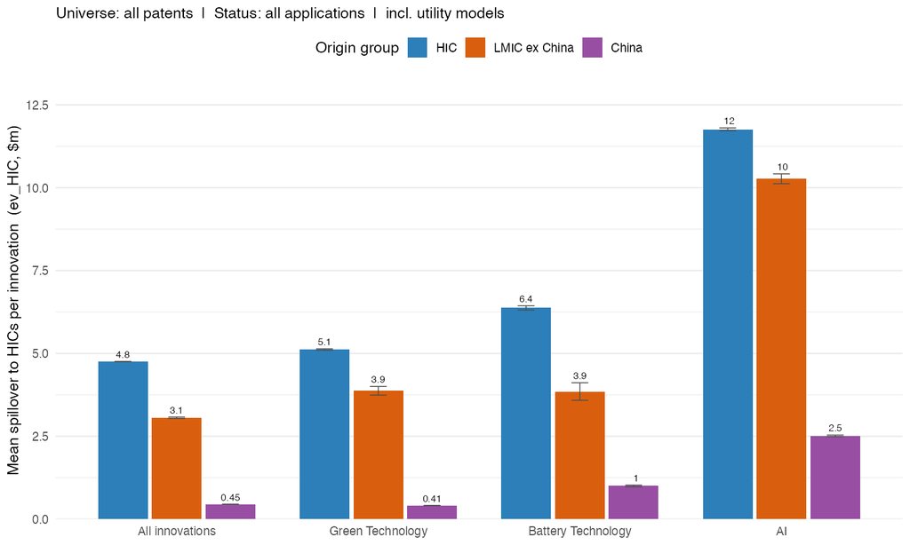

**Note.** Bars show the mean of the selected **Metric** per innovation, grouped by technology field and by origin income group (HIC, LMIC ex China, China), with ±1 SEM error bars over families. Ticking **show HIC × LMIC ex China** adds a fourth bar (darker orange) for the collaboration subset — families with at least one high-income and one non-China LMIC attribution; those families also count in the HIC and LMIC ex China bars, so the group is an overlapping cut rather than a disjoint one. All three metrics are built on the HIC-flow spillover value `ev_HIC` using the standard iseapp formulas: **ev** = `ev_HIC` ($ millions); **istrax** = `((alpha+1)/cost)·ev_HIC·[pv ≤ 2·cost]`; **avstrax** = `(pv + ev_HIC)/cost`. istrax and avstrax are reported as percentages (×100) and are defined only for families with a positive estimated R&D cost. Innovations are attributed to income groups by the country codes on the patent family (inventor and owner locations in the iseapp 2025 database); a family spanning several groups contributes once to each. The technology fields use the iseapp `tech_group` classification; “All innovations” imposes no technology filter. The **Universe** dropdown switches between all patents and multi-country patents (`fam_size_min2`); the **Status** dropdown between all applications and granted patents only (`granted`); ticking **exclude utility models** drops utility-model families (`is_um`). The **Download data (CSV)** link exports the exact numbers behind the currently selected view (technology, origin group, mean and SEM).